# **Regression**

```python
import ads as ad
```

# 1. Introduction

This report focuses on the development and evaluation of a regression model aimed at predicting the height of individuals based on skeletal measurements found in the dataset. The dataset consists of 507 observations, each containing various numeric attributes that represent bone dimensions, such as shoulder width (biacromial), pelvic breadth (pelvicBreadth), and wrist diameter (wristDiam).

The height attribute was chosen as the dependent variable for several reasons:

- **Direct Relationship with Skeletal Dimensions:** Height is inherently linked to bone structure, making it a logical and relevant choice for a model built on skeletal measurements.
- **Predictability and Interpretability:** Height is a physical characteristic less influenced by external, unmeasured factors, such as age or weight. This makes it more predictable and enhances the model’s robustness and interpretability.
- **Practical Applications:** Predicting height using skeletal dimensions is valuable in fields like anthropology, ergonomics, and forensic science.

The primary goal of focusing on height is to create a model that achieves high predictive accuracy while remaining intuitive and aligned with the dataset's attributes. The report will present the methodology, the results from the regression analysis, and the performance of the model in predicting height using the available features.

With the introduction and rationale behind the selection of the dependent variable clarified, the next section will describe the methodology used for building and evaluating the regression model.

# 2.Exploratory Data Analysis (EDA)

The dataset used for this analysis consists of 507 entries and 12 columns, as can be seen below:

```python
import pandas as pd

smd = pd.read_csv('data/anthropometric_measurements.csv')
print(smd.shape)
```

```
(507, 12)
```

The structure of the dataset was examined to understand its composition and data types:

```python
smd.info()
```

```
<class 'pandas.core.frame.DataFrame'>
RangeIndex: 507 entries, 0 to 506
Data columns (total 12 columns):
 #   Column          Non-Null Count  Dtype
---  ------          --------------  -----
 0   biacromial      507 non-null    float64
 1   pelvicBreadth   507 non-null    float64
 2   bitrochanteric  507 non-null    float64
 3   chestDepth      507 non-null    float64
 4   chestDiam       507 non-null    float64
 5   elbowDiam       507 non-null    float64
 6   wristDiam       507 non-null    float64
 7   kneeDiam        507 non-null    float64
 8   ankleDiam       507 non-null    float64
 9   age             507 non-null    int64
 10  weight          507 non-null    float64
 11  height          507 non-null    float64
dtypes: float64(11), int64(1)
memory usage: 47.7 KB
```

Having examined the basic structure of the dataset, further analysis will be conducted to uncover trends and relationships among the features.

```python
print(smd.describe())
```

```
       biacromial  pelvicBreadth  bitrochanteric  chestDepth   chestDiam  \
count  507.000000     507.000000      507.000000  507.000000  507.000000
mean    38.811440      27.829980       31.980473   19.226036   27.973767
std      3.059132       2.206308        2.030916    2.515877    2.741650
min     32.400000      18.700000       24.700000   14.300000   22.200000
25%     36.200000      26.500000       30.600000   17.300000   25.650000
50%     38.700000      28.000000       32.000000   19.000000   27.800000
75%     41.150000      29.250000       33.350000   20.900000   29.950000
max     47.400000      34.700000       38.000000   27.500000   35.600000

        elbowDiam   wristDiam    kneeDiam   ankleDiam         age      weight  \
count  507.000000  507.000000  507.000000  507.000000  507.000000  507.000000
mean    13.385207   10.542604   18.810651   13.863314   30.181460   69.147535
std      1.352906    0.944361    1.347595    1.247351    9.608472   13.345762
min      9.900000    8.100000   15.700000    9.900000   18.000000   42.000000
25%     12.400000    9.800000   17.900000   13.000000   23.000000   58.400000
50%     13.300000   10.500000   18.700000   13.800000   27.000000   68.200000
75%     14.400000   11.200000   19.600000   14.800000   36.000000   78.850000
max     16.700000   13.300000   24.300000   17.200000   67.000000  116.400000

           height
count  507.000000
mean   171.143787
std      9.407205
min    147.200000
25%    163.800000
50%    170.300000
75%    177.800000
max    198.100000
```

- **Height and Weight**: There is a noticeable variation in both height and weight, with the mean values representing typical human dimensions. This suggests that both these features should be useful for any predictive modeling, though other factors may also contribute to these characteristics (e.g., gender or body type).
- **Age and Height**: Age varies significantly in the dataset, but it is not expected to have a direct, strong correlation with height after reaching adulthood. The data also supports this, with the variation in height remaining relatively consistent across age groups.
- **Pelvic Breadth**: The pelvic breadth shows a moderate spread, indicating that skeletal features can differ moderately from one individual to another.

## Visualizing relationships between features and height

To explore the relationships between various skeletal measurements and height, scatter plots were created. The following code generates scatter plots for each feature in comparison to height:

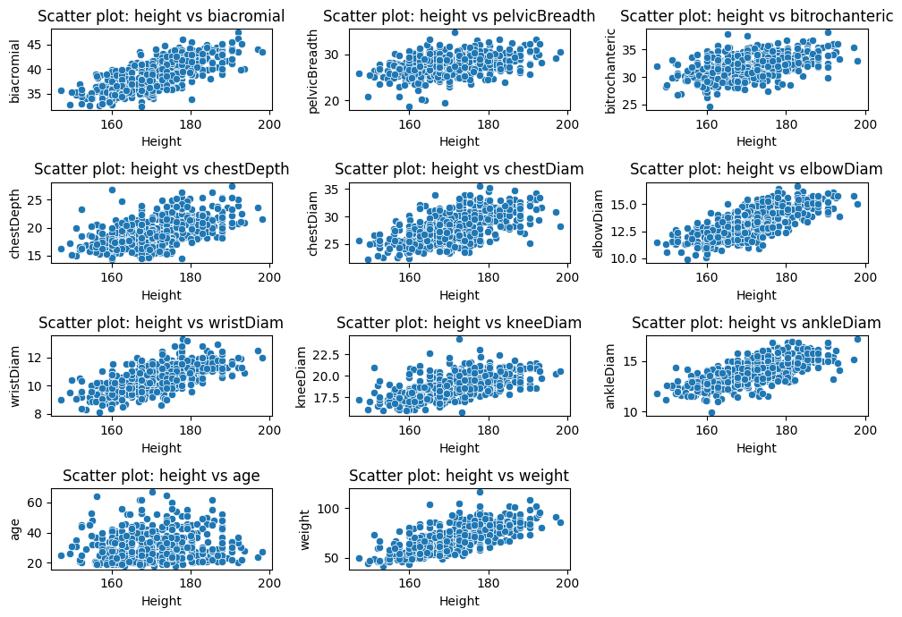

```python
import seaborn as sns
import matplotlib.pyplot as plt

smd_atts_to_plot = ['biacromial', 'pelvicBreadth', 'bitrochanteric', 'chestDepth', 'chestDiam',
                   'elbowDiam', 'wristDiam', 'kneeDiam', 'ankleDiam', 'age', 'weight']

plt.figure(figsize=(10, 7))

for i, col in enumerate(smd_atts_to_plot, 1):
    plt.subplot(4, 3, i)
    sns.scatterplot(data=smd, x='height', y=col)
    plt.title(f'Scatter plot: height vs {col}')
    plt.xlabel('Height')
    plt.ylabel(col)

plt.tight_layout()
plt.show()
```

11 scatter plots are generated, each comparing height against one of the selected skeletal measurements or attributes. By visually inspecting these plots, an understanding of the relationships between height and other features in the dataset was gained. This will help inform further modeling steps.

To further explore the relationships between height and various skeletal measurements, regression plots were created. The following code generates regression plots for each feature in comparison to height:

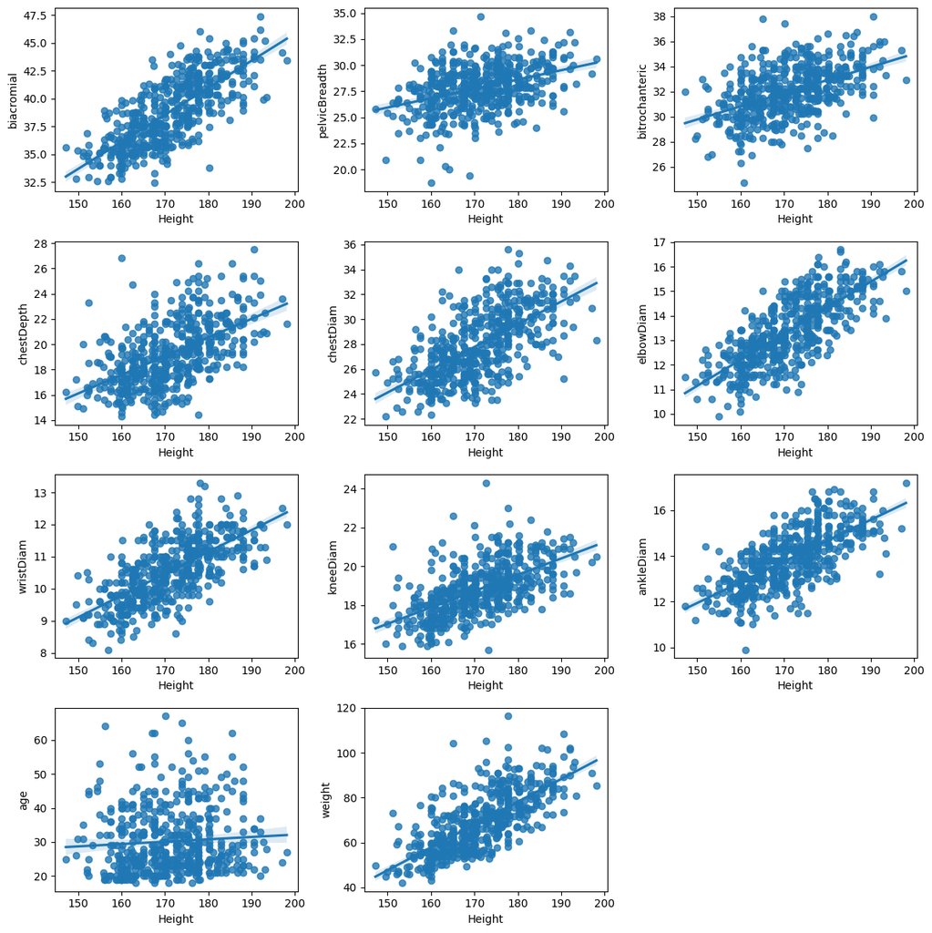

```python
plt.figure(figsize=(12, 12))

for i, col in enumerate(smd_atts_to_plot, 1):
    plt.subplot(4, 3, i)
    sns.regplot(data=smd, x='height', y=col)
    #plt.title(f'Regression plot: height vs {col}')
    plt.xlabel('Height')
    plt.ylabel(col)

plt.tight_layout()
plt.show()
```

11 regression plots are generated, each comparing height against one of the selected skeletal measurements. A regression line is fitted for each plot, showing the relationship between height and the feature. The inclination of the lines for the other attributes shows a linear relationship between height and the skeletal measurements. The horizontal line for the "age" attribute indicates that there is no significant relationship between age and height, which makes sense as height growth largely stops once adulthood is reached. This observation suggests that age is unlikely to be an important factor in predicting height, which could influence the selection of variables for future regression models.

```python
import numpy as np

np.random.seed(43)
smd_copy = smd.copy()
smd_copy['randomVariable'] = np.random.rand(len(smd))

print(smd_copy.columns)
```

```
Index(['biacromial', 'pelvicBreadth', 'bitrochanteric', 'chestDepth',
       'chestDiam', 'elbowDiam', 'wristDiam', 'kneeDiam', 'ankleDiam', 'age',
       'weight', 'height', 'randomVariable'],
      dtype='object')
```

This random variable will not serve as a meaningful predictor for the regression model but is included to demonstrate how additional variables can be added to the dataset.

```python
print(smd_copy.head())
```

```
   biacromial  pelvicBreadth  bitrochanteric  chestDepth  chestDiam  \
0        42.9           26.0            31.5        17.7       28.0
1        43.7           28.5            33.5        16.9       30.8
2        40.1           28.2            33.3        20.9       31.7
3        44.3           29.9            34.0        18.4       28.2
4        42.5           29.9            34.0        21.5       29.4

   elbowDiam  wristDiam  kneeDiam  ankleDiam  age  weight  height  \
0       13.1       10.4      18.8       14.1   21    65.6   174.0
1       14.0       11.8      20.6       15.1   23    71.8   175.3
2       13.9       10.9      19.7       14.1   28    80.7   193.5
3       13.9       11.2      20.9       15.0   23    72.6   186.5
4       15.2       11.6      20.7       14.9   22    78.8   187.2

   randomVariable
0        0.115055
1        0.609067
2        0.133391
3        0.240590
4        0.327139
```

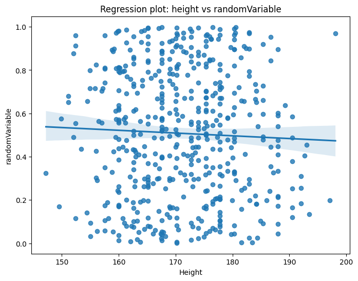

```python
plt.figure(figsize=(8, 6))

sns.regplot(data=smd_copy, x='height', y='randomVariable')
plt.title('Regression plot: height vs randomVariable')
plt.xlabel('Height')
plt.ylabel('randomVariable')

plt.show()
```

A scatter plot with a regression line was displayed, which showed no significant relationship between the height and the random variable. The regression line appeared almost horizontal, confirming that the random variable does not explain the variation in height. The plot provided further visual evidence of the lack of correlation between height and the random variable, as expected. The scatter plot with the regression line is shown below, demonstrating a near-horizontal line, suggesting no relationship between the two variables.

# 3. Model Implementation

## 1. Skcikit-learn linear regression

```python
from sklearn.linear_model import LinearRegression
# Loading data and creating the model
X_smd = smd[smd.columns.difference(['height'])]
y_smd = smd['height']
```

```python
X_smd.head()
```

|  | age | ankleDiam | biacromial | bitrochanteric | chestDepth | chestDiam | elbowDiam | kneeDiam | pelvicBreadth | weight | wristDiam |
| --- | --- | --- | --- | --- | --- | --- | --- | --- | --- | --- | --- |
| 0 | 21 | 14.1 | 42.9 | 31.5 | 17.7 | 28.0 | 13.1 | 18.8 | 26.0 | 65.6 | 10.4 |
| 1 | 23 | 15.1 | 43.7 | 33.5 | 16.9 | 30.8 | 14.0 | 20.6 | 28.5 | 71.8 | 11.8 |
| 2 | 28 | 14.1 | 40.1 | 33.3 | 20.9 | 31.7 | 13.9 | 19.7 | 28.2 | 80.7 | 10.9 |
| 3 | 23 | 15.0 | 44.3 | 34.0 | 18.4 | 28.2 | 13.9 | 20.9 | 29.9 | 72.6 | 11.2 |
| 4 | 22 | 14.9 | 42.5 | 34.0 | 21.5 | 29.4 | 15.2 | 20.7 | 29.9 | 78.8 | 11.6 |

```
Average cross-validated RMSE: 6.36 +/- 2.31
Average cross-validated R-squared: 0.24 +/- 0.21
Coefficients across all folds....
Coeficient:  [2.4644931] , Intercept:  75.54736906007341
Coeficient:  [2.17836973] , Intercept:  86.12627793443927
Coeficient:  [2.26872404] , Intercept:  83.04547499850237
Coeficient:  [2.22108238] , Intercept:  85.48561870760186
Coeficient:  [2.3445875] , Intercept:  80.13523816961542
Model coefficient:  [2.30302635]
Model intercept:  81.7600184502303
```

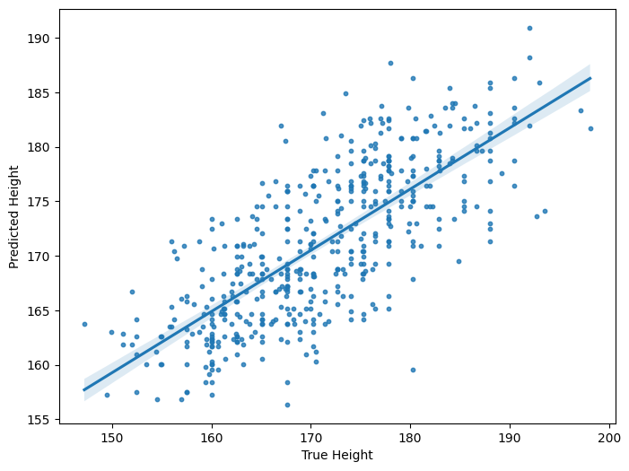

```python
lr = LinearRegression()
# Calling the cross-validation function
ad.xval_regress(lr, X_smd[['biacromial']], y_smd, lin=True, return_=True)
# Fit the model to the entire dataset
lr.fit(X_smd[['biacromial']], y_smd)
# Print model coefficient and intercept
print("Model coefficient: ", lr.coef_)
print("Model intercept: ", lr.intercept_)
# Predict on the same dataset
y_smd_pred = lr.predict(X_smd[['biacromial']])
# Plotting True vs Predicted
plt.figure(figsize=(8,6))
sns.regplot(x=y_smd, y=y_smd_pred, scatter_kws={'s': 10})
#plt.title("Regression Plot: True vs Predicted Height")
plt.xlabel("True Height")
plt.ylabel("Predicted Height")
plt.show()
```

```
Average cross-validated RMSE: 6.42 +/- 2.17
Average cross-validated R-squared: 0.21 +/- 0.23
Coefficients across all folds....
Coeficient:  [4.99140293] , Intercept:  103.79116214664673
Coeficient:  [5.01053771] , Intercept:  103.81899830292075
Coeficient:  [5.12440307] , Intercept:  102.70535018053826
Coeficient:  [5.22014467] , Intercept:  101.5049061427695
Coeficient:  [5.14043714] , Intercept:  102.65417838416711
Model coefficient:  [5.13234567]
Model intercept:  102.4462773401223
```

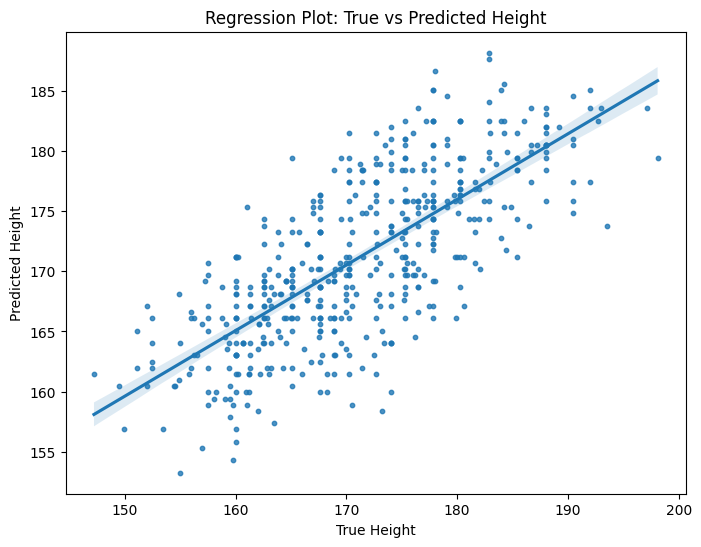

```python
lr = LinearRegression()
# Calling the cross-validation function
ad.xval_regress(lr, X_smd[['elbowDiam']], y_smd, lin=True, return_=True)
# Fit the model to the entire dataset
lr.fit(X_smd[['elbowDiam']], y_smd)
# Print model coefficient and intercept
print("Model coefficient: ", lr.coef_)
print("Model intercept: ", lr.intercept_)
# Predict on the same dataset
y_smd_pred = lr.predict(X_smd[['elbowDiam']])
# Plotting True vs Predicted
plt.figure(figsize=(8,6))
sns.regplot(x=y_smd, y=y_smd_pred, scatter_kws={'s': 10})
plt.title("Regression Plot: True vs Predicted Height")
plt.xlabel("True Height")
plt.ylabel("Predicted Height")
plt.show()
```

```
Average cross-validated RMSE: 6.79 +/- 2.93
Average cross-validated R-squared: 0.21 +/- 0.29
Coefficients across all folds....
Coeficient:  [0.47428922] , Intercept:  137.4405493987109
Coeficient:  [0.51635652] , Intercept:  135.13560123309736
Coeficient:  [0.49933326] , Intercept:  136.72052007153835
Coeficient:  [0.49039352] , Intercept:  137.8247903318451
Coeficient:  [0.52341472] , Intercept:  135.45531009311608
Model coefficient:  [0.50561356]
Model intercept:  136.181856102255
```

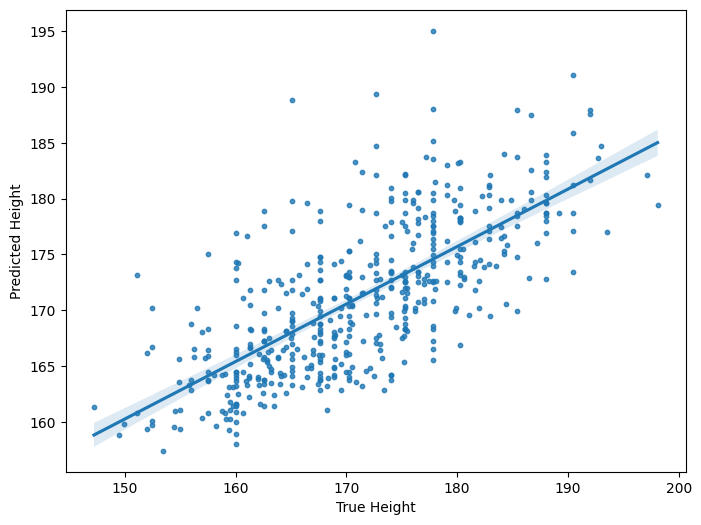

```python
lr = LinearRegression()
# Calling the cross-validation function
ad.xval_regress(lr, X_smd[['weight']], y_smd, lin=True, return_=True)
# Fit the model to the entire dataset
lr.fit(X_smd[['weight']], y_smd)
# Print model coefficient and intercept
print("Model coefficient: ", lr.coef_)
print("Model intercept: ", lr.intercept_)
# Predict on the same dataset
y_smd_pred = lr.predict(X_smd[['weight']])
# Plotting True vs Predicted
plt.figure(figsize=(8,6))
sns.regplot(x=y_smd, y=y_smd_pred, scatter_kws={'s': 10})
#plt.title("Regression Plot: True vs Predicted Height")
plt.xlabel("True Height")
plt.ylabel("Predicted Height")
plt.show()
```

```
Average cross-validated RMSE: 5.53 +/- 1.89
Average cross-validated R-squared: 0.38 +/- 0.19
Coefficients across all folds....
Coeficient:  [-0.05788615  1.81558372  1.49961002 -0.32644281 -0.54601203 -0.91963787
  1.61991078 -0.98825048  0.40109629  0.31720243 -0.04772787] , Intercept:  100.3061332637363
Coeficient:  [-0.08741576  1.22472675  1.13144938 -0.07747291 -0.22911329 -0.49018651
  1.72088039 -1.26237001  0.4471125   0.27770367  0.48406314] , Intercept:  97.4759191426929
Coeficient:  [-0.09939468  1.49883345  1.34516396 -0.06292214 -0.12483952 -0.76081592
  0.99052895 -1.15808844  0.48159033  0.24391376  1.11645578] , Intercept:  93.33635619678614
Coeficient:  [-0.06163883  1.59461772  1.39370103 -0.01528579 -0.26458542 -0.8090716
  1.76734593 -0.71317514  0.4368369   0.250669   -0.13297236] , Intercept:  86.62830454650994
Coeficient:  [-0.06954862  1.51472292  1.17635656  0.05132931 -0.18227139 -0.66140949
  1.24195274 -1.04695412  0.321673    0.28601357  0.53948141] , Intercept:  95.82200167332626
Model coefficient:  [-0.07564375  1.50470175  1.3165914  -0.09472071 -0.26982115 -0.72184791
  1.4637309  -1.04046371  0.41063737  0.27467773  0.41956151]
Model intercept:  95.0123452907645
```

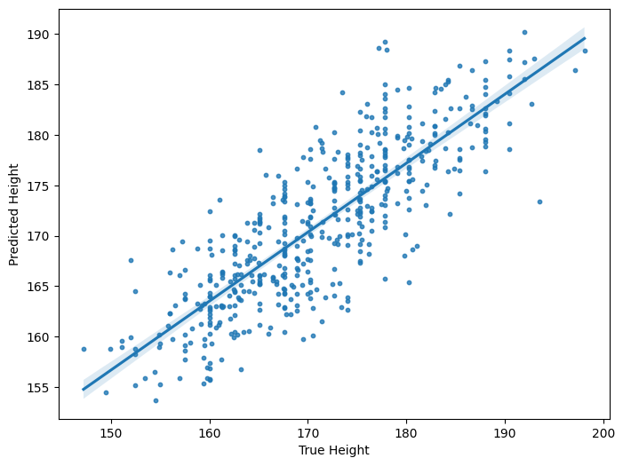

```python
lr = LinearRegression()
# Calling the cross-validation function
ad.xval_regress(lr, X_smd, y_smd, lin=True, return_=True)
# Fit the model to the entire dataset
lr.fit(X_smd, y_smd)
# Print model coefficient and intercept
print("Model coefficient: ", lr.coef_)
print("Model intercept: ", lr.intercept_)
# Predict on the same dataset
y_smd_pred = lr.predict(X_smd)
# Plotting True vs Predicted
plt.figure(figsize=(8,6))
sns.regplot(x=y_smd, y=y_smd_pred, scatter_kws={'s': 10})
#plt.title("Regression Plot: True vs Predicted Height")
plt.xlabel("True Height")
plt.ylabel("Predicted Height")
plt.show()
```

## Regression Plane

```python
import plotly.graph_objects as go
# Select the independent variables 'biacromial' and 'pelvicBreadth' to predict 'height'
X_smd_multi = smd[['biacromial', 'pelvicBreadth']]  # Choose two independent variables
y_smd = smd['height']  # The dependent variable 'height'
# Initialize the linear regression model
lr = LinearRegression()
# Calling the cross-validation function
ad.xval_regress(lr, X_smd_multi, y_smd, lin=True, return_=True)
# Train the model with the two independent variables
lr.fit(X_smd_multi, y_smd)
# Extract the intercept and the coefficients for the two variables
intercept = lr.intercept_
biacromial_coef = lr.coef_[0]
pelvicBreadth_coef = lr.coef_[1]
# Create a range for the independent variables
biacromial_range = np.linspace(X_smd_multi['biacromial'].min(), X_smd_multi['biacromial'].max(), 100)
pelvicBreadth_range = np.linspace(X_smd_multi['pelvicBreadth'].min(), X_smd_multi['pelvicBreadth'].max(), 100)
# Create a 2D grid for prediction
biacromial_range, pelvicBreadth_range = np.meshgrid(biacromial_range, pelvicBreadth_range)
# Predictions from the 2D grid
preds = intercept + biacromial_range * biacromial_coef + pelvicBreadth_range * pelvicBreadth_coef
# Create a figure using plotly.graph_objects
fig = go.Figure()
# Add the actual data points
fig.add_trace(go.Scatter3d(
    x=X_smd_multi['biacromial'],
    y=X_smd_multi['pelvicBreadth'],
    z=y_smd,
    mode='markers',
    marker=dict(size=5, color='blue'),
    name='Data points'
))
# Add the regression plane
fig.add_trace(go.Surface(
    x=biacromial_range,
    y=pelvicBreadth_range,
    z=preds,
    colorscale=[[0, 'red'], [1, 'red']],  # Set the plane color to solid red
    opacity=0.8,  # Adjust transparency
    name='Regression plane'
))
# Update layout to enforce cube-like aspect ratio and increase the window size
fig.update_layout(
    scene=dict(
        aspectmode='cube',
        xaxis_title='Biacromial',
        yaxis_title='Pelvic Breadth',
        zaxis_title='Height'
    ),
    title='3D Regression: Biacromial, Pelvic Breadth vs Height',
    width=1200,  # Increase width of the window
    height=900  # Increase height of the window
)
# Show the plot
fig.show()
```

```
Average cross-validated RMSE: 6.17 +/- 2.09
Average cross-validated R-squared: 0.28 +/- 0.20
Coefficients across all folds....
Coeficient:  [2.32224862 0.58774046] , Intercept:  64.66620130650132
Coeficient:  [2.0345404  0.71676864] , Intercept:  71.76867615909971
Coeficient:  [2.10008415 0.72170561] , Intercept:  69.45532798797647
Coeficient:  [2.10006511 0.76014639] , Intercept:  68.8881931880841
Coeficient:  [2.12457279 0.75438786] , Intercept:  67.92168991455794
```

[figure not shown]

```
Average cross-validated RMSE: 5.53 +/- 1.89
Average cross-validated R-squared: 0.38 +/- 0.19
Coefficients across all folds....
Coeficient:  [-0.05788615  1.81558372  1.49961002 -0.32644281 -0.54601203 -0.91963787
  1.61991078 -0.98825048  0.40109629  0.31720243 -0.04772787] , Intercept:  100.3061332637363
Coeficient:  [-0.08741576  1.22472675  1.13144938 -0.07747291 -0.22911329 -0.49018651
  1.72088039 -1.26237001  0.4471125   0.27770367  0.48406314] , Intercept:  97.4759191426929
Coeficient:  [-0.09939468  1.49883345  1.34516396 -0.06292214 -0.12483952 -0.76081592
  0.99052895 -1.15808844  0.48159033  0.24391376  1.11645578] , Intercept:  93.33635619678614
Coeficient:  [-0.06163883  1.59461772  1.39370103 -0.01528579 -0.26458542 -0.8090716
  1.76734593 -0.71317514  0.4368369   0.250669   -0.13297236] , Intercept:  86.62830454650994
Coeficient:  [-0.06954862  1.51472292  1.17635656  0.05132931 -0.18227139 -0.66140949
  1.24195274 -1.04695412  0.321673    0.28601357  0.53948141] , Intercept:  95.82200167332626
```

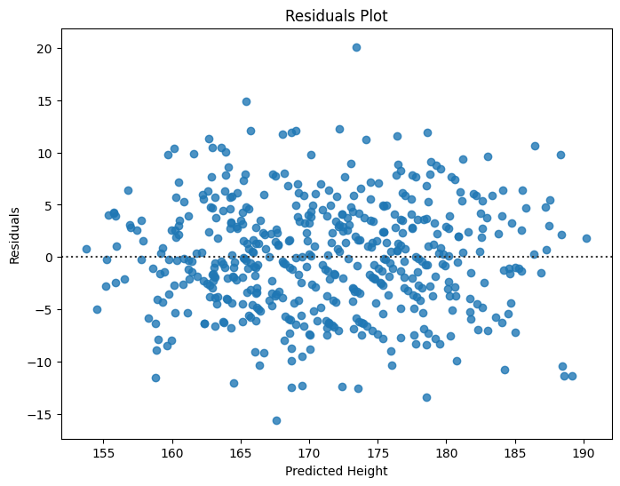

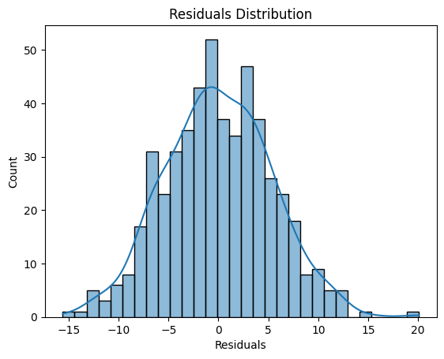

```python
from sklearn.metrics import root_mean_squared_error, r2_score

lr = LinearRegression()
# Calling the cross-validation function
ad.xval_regress(lr, X_smd, y_smd, lin=True, return_=True)
# Fit the model to the entire dataset
lr.fit(X_smd, y_smd)
residuals = y_smd - y_smd_pred
# Plotting residuals
plt.figure(figsize=(8, 6))
sns.residplot(x=y_smd_pred, y=residuals, line_kws={'color': 'red', 'lw': 2})
plt.xlabel("Predicted Height")
plt.ylabel("Residuals")
plt.title("Residuals Plot")
plt.show()
# Additional diagnostic: Check if residuals are normally distributed
sns.histplot(residuals, kde=True, bins=30)
plt.title("Residuals Distribution")
plt.xlabel("Residuals")
plt.show()
```

```python
pd.set_option('display.max_rows', None)  # No limit on the number of rows printed

# Display numerical data of the residuals plot
print("\nResiduals Plot Data:")
print("Residuals:")
print(residuals)
```

```
Residuals Plot Data:
Residuals:
0      -1.823641
1      -3.697075
2      20.101699
3       5.354343
4       6.219927
5       3.628873
6      -0.998733
7       1.903673
8      -1.917588
9       2.385325
10      5.530597
11     -7.214164
12      1.768520
```

[output cut: 495 more lines]

### Residual Analysis:

- The residual plot and distribution help assess whether the model is well-fitted:
  - The **residuals plot** shows the differences between the predicted and actual values. Ideally, the residuals should show no obvious pattern, which suggests that the model is appropriate for the data.
  - The **residual distribution** seems to be fairly symmetric, though some outliers (such as large positive or negative residuals) suggest that there may be certain observations where the model's predictions are off significantly.

## Support Vector Regression (SVR)

```python
from sklearn.svm import SVR
from sklearn.model_selection import cross_validate
from sklearn.model_selection import GridSearchCV

# Define the SVR model
svr = SVR()

# Define the hyperparameter grid for SVR
param_grid = {
    'kernel': ['linear', 'rbf', 'poly', 'sigmoid'],
    'C': [0.1, 1, 10, 50],
    'epsilon': [0.1, 0.5, 1]
}

# Perform GridSearchCV to find the best parameters
grid_search = GridSearchCV(estimator=svr, param_grid=param_grid, scoring='neg_mean_squared_error', cv=5, n_jobs=-1)
grid_search.fit(X_smd, y_smd)  # Use your actual training data

# Best parameters found by GridSearchCV
best_svr = grid_search.best_estimator_
best_params = grid_search.best_params_

print(f"Best SVR parameters: {best_params}")


# Now use the best model to perform cross-validation using xval_regress
print("\nPerforming cross-validation using the best SVR model:")
ad.xval_regress(best_svr, X_smd, y_smd, lin=False)
```

```
Best SVR parameters: {'C': 10, 'epsilon': 1, 'kernel': 'poly'}

Performing cross-validation using the best SVR model:
Average cross-validated RMSE: 5.54 +/- 2.21
Average cross-validated R-squared: 0.38 +/- 0.18
```

## Elastic Net Regression

Elastic Net Regression is a regularized regression method that combines the properties of both Lasso and Ridge regression. It is used to model relationships between a dependent variable and independent variables while penalizing the model's complexity to prevent overfitting, making it particularly useful when there are correlated predictors.

```python
from sklearn.linear_model import ElasticNet

# Define ElasticNet model
elastic_net = ElasticNet()

# Now use the best model to perform cross-validation using xval_regress
print("\nPerforming cross-validation using the best ElasticNet model:")
ad.xval_regress(elastic_net, X_smd, y_smd, lin=True)
```

```
Performing cross-validation using the best ElasticNet model:
Average cross-validated RMSE: 5.65 +/- 1.85
Average cross-validated R-squared: 0.37 +/- 0.18
Coefficients across all folds....
Coeficient:  [-0.05682494  0.74807678  1.28221958 -0.         -0.04916952 -0.25314105
  0.53475264 -0.          0.14306997  0.22914009  0.        ] , Intercept:  93.52072535584396
Coeficient:  [-0.08621994  0.47576045  0.96596198  0.         -0.         -0.
  0.60758388 -0.          0.19463954  0.25648625  0.        ] , Intercept:  98.16991474311114
Coeficient:  [-0.08058612  0.65902845  1.19098195 -0.          0.         -0.17154706
  0.42382667 -0.          0.23651094  0.23281885  0.04828508] , Intercept:  94.1591794925731
Coeficient:  [-0.06244787  0.58116399  1.17084945  0.         -0.         -0.21950489
  0.60637169  0.          0.16772495  0.25142518  0.        ] , Intercept:  95.74371310635271
Coeficient:  [-0.04871361  0.6509931   1.00047861  0.         -0.         -0.11670186
  0.5048802  -0.          0.13808507  0.28079109  0.        ] , Intercept:  98.20164810705478
```

```python
from sklearn.linear_model import ElasticNet

# Define ElasticNet model
elastic_net = ElasticNet()

# Hyperparameter grid to search
param_grid = {
    'alpha': [0.1, 0.5, 1, 10],  # Regularization strength
    'l1_ratio': [0.1, 0.5, 0.9]  # The ratio between Lasso (L1) and Ridge (L2)
}

# Grid search with cross-validation
grid_search = GridSearchCV(estimator=elastic_net, param_grid=param_grid, cv=5, scoring='neg_mean_squared_error')
grid_search.fit(X_smd, y_smd)  # Make sure to use the proper training data (X_smd, y_smd)

# Best parameters from GridSearch
best_params = grid_search.best_params_
print(f"Best ElasticNet parameters: {best_params}")

# Model performance
best_model = grid_search.best_estimator_

# Now use the best model to perform cross-validation using xval_regress
print("\nPerforming cross-validation using the best ElasticNet model:")
ad.xval_regress(best_model, X_smd, y_smd, lin=True)
```

```
Best ElasticNet parameters: {'alpha': 0.1, 'l1_ratio': 0.1}

Performing cross-validation using the best ElasticNet model:
Average cross-validated RMSE: 5.51 +/- 1.80
Average cross-validated R-squared: 0.39 +/- 0.18
Coefficients across all folds....
Coeficient:  [-0.05880678  1.56698148  1.48246208 -0.29995345 -0.46900486 -0.82707934
  1.37117628 -0.75562437  0.38441259  0.29992064  0.15027329] , Intercept:  98.06244641033305
Coeficient:  [-0.08882965  1.09479288  1.11389967 -0.0728998  -0.18642163 -0.41513771
  1.45213027 -0.94189453  0.41433986  0.26783637  0.4611759 ] , Intercept:  96.28761117916773
Coeficient:  [-0.0972662   1.32672827  1.3306518  -0.06473247 -0.09352115 -0.682512
  0.94657547 -0.89201069  0.45497391  0.23834951  0.8758286 ] , Intercept:  92.73417100393507
Coeficient:  [-0.06247379  1.37735815  1.36751483 -0.         -0.22473327 -0.7352083
  1.48007313 -0.50064933  0.39551607  0.2487641   0.03925523] , Intercept:  86.72534218285709
Coeficient:  [-0.06718468  1.33617832  1.1597708   0.04221539 -0.13955437 -0.59799922
  1.11929151 -0.80817546  0.30278906  0.28122327  0.4822411 ] , Intercept:  95.1724796881324
```

```python
from sklearn.linear_model import Ridge
ridge = Ridge(random_state=34)
ad.xval_regress(ridge, X_smd, y_smd, lin=True)
```

```
Average cross-validated RMSE: 5.53 +/- 1.88
Average cross-validated R-squared: 0.38 +/- 0.19
Coefficients across all folds....
Coeficient:  [-0.05793334  1.80742183  1.49922621 -0.32586276 -0.54370926 -0.91709334
  1.61147369 -0.98133765  0.400925    0.31664055 -0.03810092] , Intercept:  100.22703439463858
Coeficient:  [-0.08745526  1.22106936  1.13106242 -0.07764366 -0.2279599  -0.48817383
  1.71206098 -1.25253947  0.44630478  0.27741951  0.48461787] , Intercept:  97.43768873455132
Coeficient:  [-0.09931835  1.49363631  1.34485647 -0.06333482 -0.12412855 -0.75870624
  0.99041155 -1.15008094  0.48097301  0.24378906  1.10800522] , Intercept:  93.32445613970769
Coeficient:  [-0.06168003  1.58796083  1.39304581 -0.01491832 -0.26344724 -0.8071692
  1.75756968 -0.70715941  0.43583387  0.25061151 -0.12461041] , Intercept:  86.62327526091427
Coeficient:  [-0.06947992  1.50927287  1.17596764  0.05111463 -0.18115527 -0.65981687
  1.23848166 -1.03999189  0.32119309  0.28587921  0.5385689 ] , Intercept:  95.79908294817183
```

```
Average cross-validated RMSE: 5.53 +/- 1.89
Average cross-validated R-squared: 0.38 +/- 0.19
Average cross-validated RMSE: 5.53 +/- 1.89
Average cross-validated R-squared: 0.38 +/- 0.19
Average cross-validated RMSE: 5.53 +/- 1.89
Average cross-validated R-squared: 0.38 +/- 0.19
Average cross-validated RMSE: 5.53 +/- 1.89
Average cross-validated R-squared: 0.38 +/- 0.19
Average cross-validated RMSE: 5.53 +/- 1.89
Average cross-validated R-squared: 0.38 +/- 0.19
Average cross-validated RMSE: 5.53 +/- 1.89
Average cross-validated R-squared: 0.38 +/- 0.19
Average cross-validated RMSE: 5.53 +/- 1.89
Average cross-validated R-squared: 0.38 +/- 0.19
Average cross-validated RMSE: 5.53 +/- 1.89
Average cross-validated R-squared: 0.38 +/- 0.19
Average cross-validated RMSE: 5.53 +/- 1.89
Average cross-validated R-squared: 0.38 +/- 0.19
Average cross-validated RMSE: 5.53 +/- 1.89
Average cross-validated R-squared: 0.38 +/- 0.19
Average cross-validated RMSE: 5.53 +/- 1.89
Average cross-validated R-squared: 0.38 +/- 0.19
Average cross-validated RMSE: 5.53 +/- 1.89
Average cross-validated R-squared: 0.38 +/- 0.19
Average cross-validated RMSE: 5.53 +/- 1.88
Average cross-validated R-squared: 0.38 +/- 0.19
Average cross-validated RMSE: 5.53 +/- 1.88
Average cross-validated R-squared: 0.38 +/- 0.19
Average cross-validated RMSE: 5.53 +/- 1.88
Average cross-validated R-squared: 0.38 +/- 0.19
Average cross-validated RMSE: 5.53 +/- 1.88
Average cross-validated R-squared: 0.38 +/- 0.19
Average cross-validated RMSE: 5.53 +/- 1.88
Average cross-validated R-squared: 0.38 +/- 0.19
Average cross-validated RMSE: 5.53 +/- 1.88
Average cross-validated R-squared: 0.38 +/- 0.19
Average cross-validated RMSE: 5.53 +/- 1.88
Average cross-validated R-squared: 0.38 +/- 0.19
Average cross-validated RMSE: 5.53 +/- 1.88
Average cross-validated R-squared: 0.38 +/- 0.19
Average cross-validated RMSE: 5.53 +/- 1.88
Average cross-validated R-squared: 0.38 +/- 0.19
Average cross-validated RMSE: 5.53 +/- 1.87
Average cross-validated R-squared: 0.38 +/- 0.19
Average cross-validated RMSE: 5.53 +/- 1.87
Average cross-validated R-squared: 0.38 +/- 0.19
Average cross-validated RMSE: 5.53 +/- 1.87
Average cross-validated R-squared: 0.38 +/- 0.19
Average cross-validated RMSE: 5.52 +/- 1.86
Average cross-validated R-squared: 0.38 +/- 0.18
Average cross-validated RMSE: 5.52 +/- 1.86
Average cross-validated R-squared: 0.38 +/- 0.18
Average cross-validated RMSE: 5.52 +/- 1.86
Average cross-validated R-squared: 0.38 +/- 0.18
```

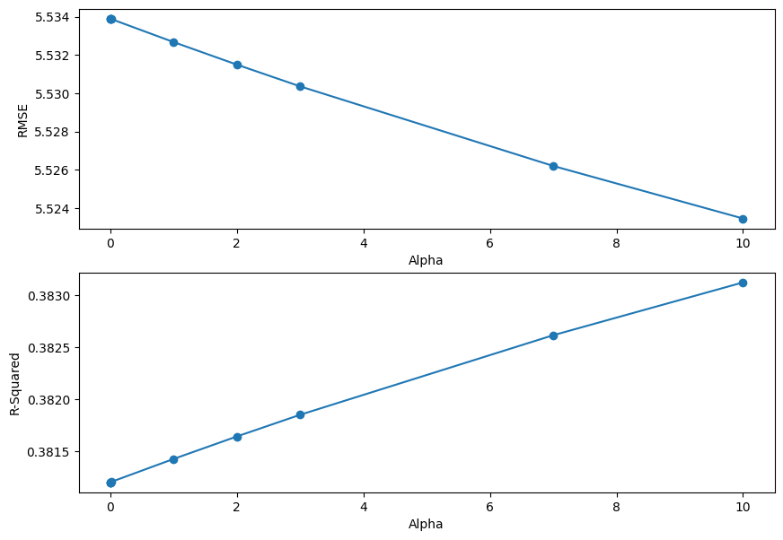

```python
alphas = [1e-8, 1e-7, 1e-3, 1e-2, 1, 2, 3, 7, 10]
rmses = []
r2s = []
for alpha in alphas:
  ridge = Ridge(alpha=alpha, random_state=34)
  ad.xval_regress(ridge, X_smd, y_smd, lin=False, return_=True)
  rmses.append(ad.xval_regress(ridge, X_smd, y_smd, lin=False, return_=True)[0])
  r2s.append(ad.xval_regress(ridge, X_smd, y_smd, lin=False, return_=True)[1])

plt.figure(figsize=(10,7))
plt.subplot(2, 1, 1)
plt.plot(alphas, rmses, marker='o')
plt.xlabel('Alpha')
plt.ylabel('RMSE')
plt.subplot(2, 1, 2)
plt.plot(alphas, r2s, marker='o')
plt.xlabel('Alpha')
plt.ylabel('R-Squared')
```